# Correlation Maps

In this example, we will demonstrate the use of correlation maps. In particular, we will look at correlations among a `ws_monitor` site and our `bs_grid` of bluesky model data.

To start, lets look at a region and timeframe that is significantly affected by wildfire smoke in order to gain a sense of what correlations mean.

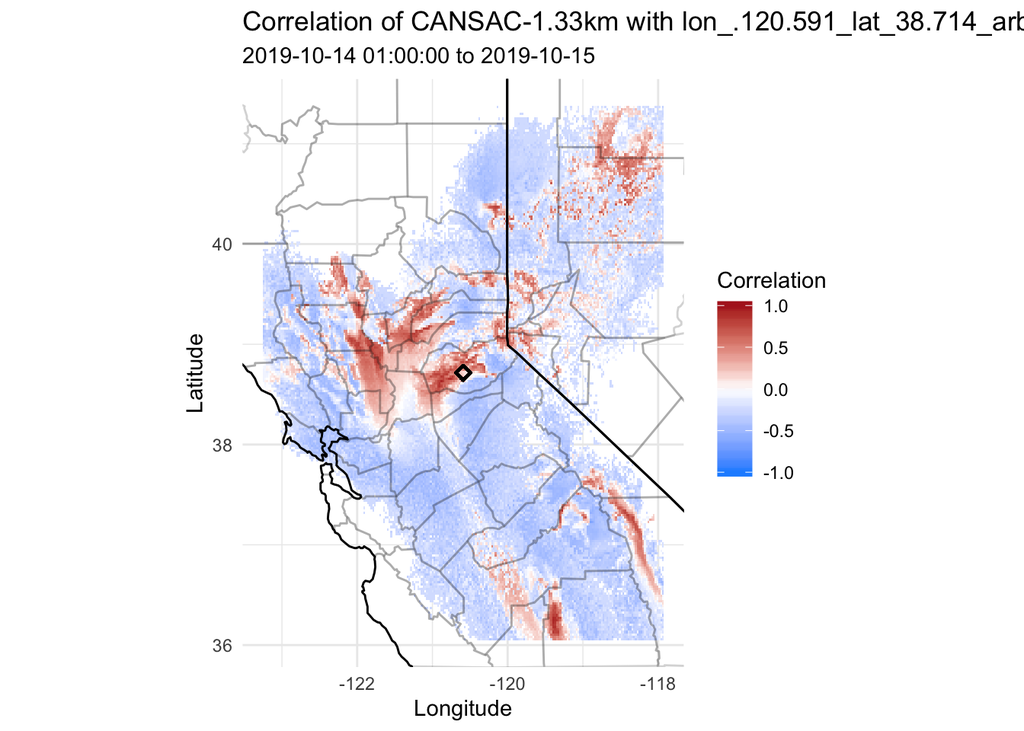

```r
pollock_pines <-
      monitor_load(20191014, 20191015) %>%
      monitor_subset(monitorIDs = "lon_.120.591_lat_38.714_arb2.1008")

bs_grid <- bluesky_load(model = 'CANSAC-1.33km',modelRun = 20191014)

grid_correlationMap(bs_grid = bs_grid, ws_monitor = pollock_pines, plotter = 'gg')
```

Just as the legend states, red is a postive correlation with the monitor reading (highlighted with a black square) and blue is a negative correlation. White (0.0) is no correlation. We can see that in the area surronding the monitor, there is a strong correlation to the model output and the monitor’s reading.

Let’s try a monitor that does not correlate well to its region.

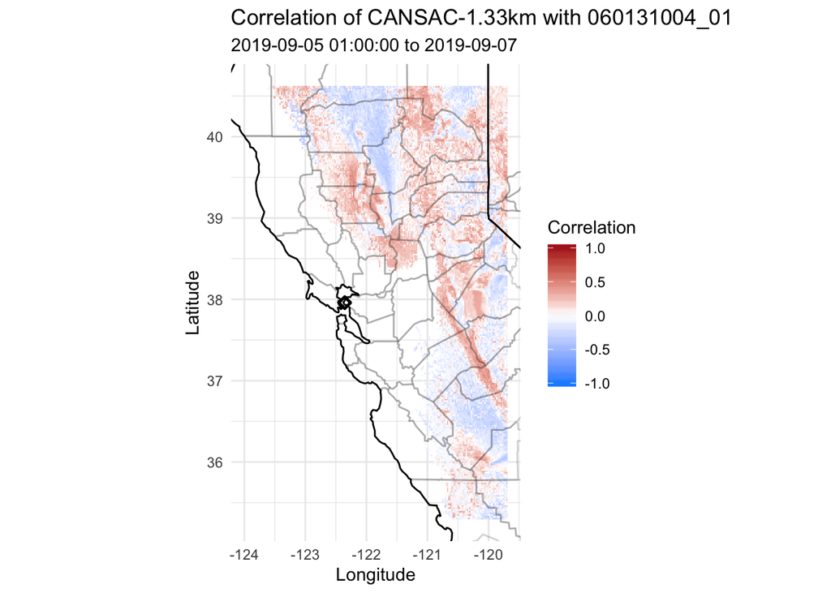

```r
other_monitor <- monitor_load(20190905, 20190907) %>%
  monitor_subset(monitorIDs = '060131004_01')

bs_grid <- bluesky_load(model = 'CANSAC-1.33km',modelRun = 20190905, subDir = 'forecast')

grid_correlationMap(bs_grid = bs_grid, ws_monitor = other_monitor, plotter = 'gg')
```

Using a correlation map, we can examine the preformance of the monitor and BlueSky models. Ideally, we’d like to investigate further to compare such correlations.

– Mazama Science